# 個人プロジェクト

花田航太

2021/12/17

## 1.はじめに

実際に箇条書きである必要はないが、必要な要素としては以下の通り。

1.なぜこのテーマを取り上げたのか？

-私がこのテーマを取り上げた理由は、私の趣味が競馬観戦であるからである。 私が競馬観戦をする際は様々なデータを見て購入する勝ち馬投票券を選択している。例えば、馬主、調教師、騎手、血統、戦績など様々な情報からである。しかし前記のような予想ツールは公開されているデータがあるのが前提である。そんな中で我々のような競馬ファンの多くが自らの経験則から正確なデータが無いのにも関わらず予想をする場合がある。時にはオカルトチックな予想をする人さえいる。その中の1つが私が今回取り上げたテーマである。競馬ファンであれば１回は聞いたことがあるであろう仮説だ。そんな自分の中で根拠は無いが今まで予想のコンテンツになっていたこの仮説が本当に正しいのか自分の分析によって明らかになれば面白いなと思ったのだ。趣味をテーマにすることによって、分析の結果から考察をしていく上で元からの自分が持っている知識を前提に解釈できるという旨みもあるはずだ。

## 2.仮説

本仮説は以下の通りである

> 「日本中央競馬会のレースにおいて牝馬限定戦は牡馬限定戦と比較して配当が荒れやすいのは事実か。」

## 3.問題の背景

今回の仮説を分析する為に2011年～2020年までのデータをエクセルにまとめた。 牝馬であれば、桜花賞、オークス、秋華賞、牡馬であれば、皐月賞、ダービー、菊花賞に限定した。 全レースにおける、１～３着の人気を集めた。

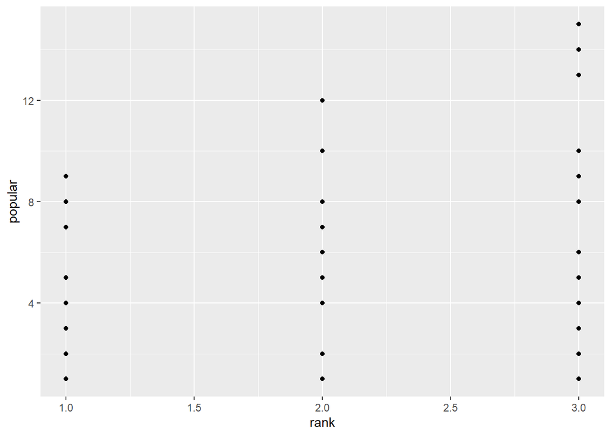

```r
setwd("C:/Rdata")
library(readxl)
hinba<-readxl::read_excel("keiba1.xlsx",skip=2,sheet=1)
boba<-readxl::read_excel("keiba1.xlsx",skip=2,sheet=2)
library(datasets)
library(psych)
descriptive_statistics<-describe(anscombe,skew = FALSE, ranges = FALSE)
library(patchwork)
library(ggplot2)
ggplot(data=hinba)+
  geom_point(aes(x=rank,y=popular))
```

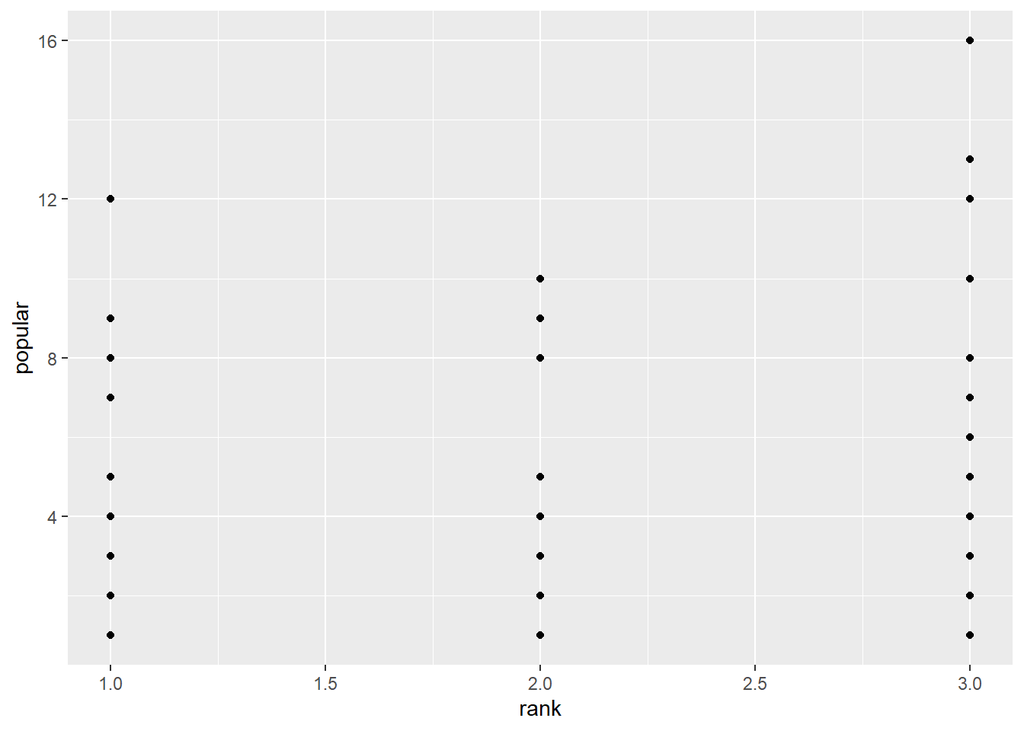

```r
ggplot(data=boba)+
  geom_point(aes(x=rank,y=popular))
```

```r
summary(hinba$popular)
```

```
##    Min. 1st Qu.  Median    Mean 3rd Qu.    Max.
##   1.000   2.000   3.000   4.167   6.000  15.000
```

```r
summary(boba$popular)
```

```
##    Min. 1st Qu.  Median    Mean 3rd Qu.    Max.
##   1.000   2.000   3.000   4.422   7.000  16.000
```

```r
table(hinba$popular)
```

```
##
##  1  2  3  4  5  6  7  8  9 10 12 13 14 15
## 19 19 13  7  7  4  6  5  4  2  1  1  1  1
```

```r
table(boba$popular)
```

```
##
##  1  2  3  4  5  6  7  8  9 10 12 13 16
## 21 11 17  8  7  1  5  8  3  4  3  1  1
```

## 4.分析

### 4.1データの紹介

- 使用するデータの紹介 [JRAのホームページ](https://www.jra.go.jp/datafile/seiseki/)

### 4.2分析方法

```r
A<-lm(rank~popular,data=hinba)
summary(A)
```

```
##
## Call:
## lm(formula = rank ~ popular, data = hinba)
##
## Residuals:
##      Min       1Q   Median       3Q      Max
## -1.44147 -0.71076  0.01522  0.62703  1.28924
##
## Coefficients:
##             Estimate Std. Error t value Pr(>|t|)
## (Intercept)  1.61942    0.13173  12.293  < 2e-16 ***
## popular      0.09134    0.02492   3.665 0.000422 ***
## ---
## Signif. codes:  0 '***' 0.001 '**' 0.01 '*' 0.05 '.' 0.1 ' ' 1
##
## Residual standard error: 0.7691 on 88 degrees of freedom
## Multiple R-squared:  0.1324, Adjusted R-squared:  0.1226
## F-statistic: 13.43 on 1 and 88 DF,  p-value: 0.000422
```

```r
B<-lm(rank~popular,data=boba)
summary(B)
```

```
##
## Call:
## lm(formula = rank ~ popular, data = boba)
##
## Residuals:
##      Min       1Q   Median       3Q      Max
## -1.61833 -0.72076  0.08567  0.70806  1.27924
##
## Coefficients:
##             Estimate Std. Error t value Pr(>|t|)
## (Intercept)   1.6392     0.1336  12.265  < 2e-16 ***
## popular       0.0816     0.0239   3.414  0.00097 ***
## ---
## Signif. codes:  0 '***' 0.001 '**' 0.01 '*' 0.05 '.' 0.1 ' ' 1
##
## Residual standard error: 0.7759 on 88 degrees of freedom
## Multiple R-squared:  0.117,  Adjusted R-squared:  0.1069
## F-statistic: 11.66 on 1 and 88 DF,  p-value: 0.0009699
```

### 4.3分析結果

結果は牝馬限定戦よりもより牡馬限定戦のほうが荒れやすい傾向にある。

## 5.考察

今回の分析結果からみて、この予測方法で勝ち馬投票券を購入するのは良くないという事が分かった。